# Untitled_1-100

# Другие виды листинга

При работе над длинной или сложной программой можно получить два других вида листинга с дополнительной информацией: листинг перекрестных ссылок и листинг распределения памяти.

# Листинг перекрестных ссылок

Листинг перекрестных ссылок указывает номер строки, в которой определен каждый идентификатор, и номера тех строк, в которых есть ссылки на него. Перед генерацией листинга перекрестных ссылок надо получить файл перекрестных ссылок с расширением имени (.CRF). Для этого надо в ответ на запрос Aссемблера "Cross reference" ввести имя программы. В нашем случае правильным ответом будет

```
Cross reference [NUL.CRF]: ex_prog
```

Помимо создания файла с расширением .CRF, указание имени в ответ на этот запрос заставляет Ассемблер включить номера строк в его обычный листинговый (.LST) файл. После завершения трансляции введите команду `b>a:cref` и дайте следующие ответы на появляющиеся запросы:

```
Cref filename [.CRF]: ex_prog
List filename [EX_PROG.REF]: (нажмите клавишу вооврата каретки)
```

Когда операционная система DOS вновь выдаст приглашение к вводу, изобразите на экране листинг перекрестных ссылок командой

```
B>type ex_prog.ref
```

Как показано на рис. 2.4, Вы получите имя каждого идентификатора программы, номер строки, где он определен (помеченный знаком # ), и все номера строк других операторов, которые на него ссылаются.

[output not shown]

Рис. 2.4. Листинг перекрестных ссылок для примера программы

Стр. 60

# листинг распределения памяти

Листинг распределения памяти содержит сводные сведения о сегментах программы. Для каждого сегмента указываются смещение адреса его начала (Start) и конца (Stop), длина сегмента в байтах и его категория (CODE - сегмент команд, DATA - сегмент данных, EXTRA - дополнительный сегмент и STACK - сегмент стека). Листинг распределения памяти выдается загрузчиком LINK. Для этого его надо вызвать командой

```
B>a:link имя-программы...;
```

```
B>type ex_prog.map
```

Если Вы хотите получить листинг на бумаге, то сначала наберите Ctrl-PrtSc. Листинг должен выглядеть так, как показано на рис. 2.5. Когда его печать закончится, отмените печать появляющегося на экране текста, еще раз набрав Ctrl-PrtSc.

```
A>type ex-prog.map
```

| Start | Stop | Length | Name | Class |
| --- | --- | --- | --- | --- |
| 00000H | 001FFH | 00200H | STACK | STACK |
| 00200H | 00207H | 00008H | DSEG | DATA |
| 00210H | 00246H | 00037H | CSEG | CODE |

```
Program entry point at 0021:0000
```

Рис. 2.5. Листинг распределения памяти для примера программы

# 2.8. МОДЕЛИ СТРУКТУРЫ ПРОГРАММЫ

В этом разделе мы представим обобщенные модели, которыми можно пользоваться при повторении программ этой книги или при разработке собственных программ. Эти модели включают в себя все компоненты, которые должна иметь каждая программа. Вам нужно только заполнить их данными и командами, требующимися для Вашей программы. Пример 2.1 является моделью исходного модуля, представляющего собой либо законченную программу, либо основной программный модуль, который должен загружаться вместе со вспомогательными модулями. Если подобный основной модуль должен содержать ссылки на элементы вспомогательных модулей, то в нем должен быть оператор EXTRN, перечисляющий эти элементы. Пример 2.2 показывает модель вспомогательного модуля, который должен загружаться вместе с основным модулем примера 2.1. Обратите внимание на следующее:

- 1. Поскольку сегмент команд вспомогательного модуля имеет то же имя (CSEG), что и сегмент команд основного модуля, то процедура PNAME определена с атрибутом NEAR. Для вызова этой процедуры из сегмента команд, имеющего другое имя, определите процедуру PNAME с атирибутом FAR.
- 1. Поскольку, сегмент данных этого модуля имеет то же имя, что и сегмент данных основного модуля, то мы не инициализировали регистр DS. В этом нет нужды, так как команды основного модуля его уже инициализировали. Однако в случае, если сегмент данных основного модуля имеет другое имя, надо вставить команды загрузки начального значения регистра DS и во вспомогательный модуль,
- 1. В примере процедура имеет условное имя PNAME. При написании своего модуля замените PNAME на имя своей процедуры в следующих трех местах: в операторе PUBLIC в начале модуля, в операторе PROC в его середине и операторе ENDP в конце модуля.
- 1. Данный модуль имеет оператор PUBLIC, соответствующий оператору EXTRN основного модуля. Если основной модуль содержит вызов процедуры PNAME, то он должен содержать оператор EXTRN PNAME: NEAR.
- 1. Псевдооператор END данного модуля не имеет метки, поскольку этот модуль не основной.

Стр. 61

Вы можете создать эти модели так же, как и любую другую программу, используя EDLIN или какой-либо иной редактор, или программу обработки текста. Затем, когда Вам потребуется набрать текст программы, скопируйте соответствующую модель и дайте копии имя Вашей программы (например, сару mainmod.asm newprog. asm). Затем с помощью редактора вставьте в эту копию свои команды и данные.

# Пример 2.1. модель основного программного модуля

```
TITLE (Разместите здесь заголовок)
        PAGE       ,132
(Если требуется оперативно EXTRN, поместите его здесь)
        DB  64 DUP('STACK')  ;Область стека
STACK   ENDS
DSEG    SEGMENT  PARA PUBLIC 'DATA'
    (Поместите здесь данные)
DSEG  ENDS
SUBTTL  Основная программа
      PAGE
```

```
CSEG  SEGMENT  PARA  PUBLIC 'CODE'
      ASSUME  CS:CSEG, DS:DSEG, SS:STACK
ENTRY PROC FAR ; Точка входа
; Занести в стек такие начальные эначения, чтобы праграмма
; могла возвратить управление отладчику DEBUG
        PUSH DS
        SUB AX,AX
        PUSH AX
;Инициировать адрес сегмента данных
        MOV Ax, DSEG
        MOV DS, AX
(Поменять здесь команды)
        RET ; Возвратить управление DOS или DEBUG
ENTRY   ENDP
CSEG    ENDS
        END  ENTRY
```

Стр. 62

# Пример 2.2. модель вспомогательного модуля

```
TITLE  (Разместить здесь заголовок)
        PAGE    ,132
        PUBLIC  PNAME
(Если требуется, поместите здесь оператор PUBLIC для переменных сегмкнта данных)
DSEG    SEGMENT  PARA  PUBLIC  DATA
DSEG    ENDS
CSEG    SEGMENT  PARA  PUBLIC  'CODE'
        ASSUME   CS:CSEG, DS:DSEG
PNAME   PROC     NEAR
(Поместите здесь команды)
;Возвратиться в вызвавшую программу
        RET
PNAME   ENDP
CSEG    ENDS
        END
```

# 2.9. ДОПОЛНИТЕЛЬНЫЕ ПСЕВДООПЕРАТОРЫ

# Псевдооператоры данных

Мы можем подразделить дополнительные псевдооператоры данных Ассемблера на псевдооператоры определения блока и псевдооператоры управления трансляцией (табл. 2.10).

Стр. 63

# Таблица 2.10. Дополнительные псевдооператоры данных

- Псевдооператор - Функция -
- Определение блока GROUP - Формат: имя GROUP имя-сег $[$,...$]$ - объединяет указанные сегменты в группу под одним именем так, чтобы они разместились в одном физическом сегменте объемом 64 килобайт.
- LABEL - Формат: имя LABEL тип. Задает атрибут для имя.
- Управление трансляцией ORG - Формат: ORG выражение. Полагает счетчик адреса равным значению выражение. Ассемблер присвоит этот адрес следующему объектному коду.
- EVEN - ормат: EVEN. Сдвигает значение счетчика адреса к ближайшему четному байту.

# Псевдооператоры определения блока

Псевдооператор GROUP (группа) собирает несколько сегментов в группу под одним именем так, чтобы поместить их в один блок памяти объемом в 64К. Этот псевдооператор Вам понадобится в том случае, если требуется разработать программу типа .COM (команда операционной системы), которая должна состоять из одного блока. Например, если у Вашей программы сегмент команд имеет имя CODESEG, а сегмент данных - DATASEG, то их можно сгруппировать в один блок объемом 64K по имени CGROUP следующим образом:

```
CGROUP   GROUP    CODESEG, DATASEG
DATASEG  SEGMENT  PARA PUBLIC 'DATA'
         ..
         ..
DATASEG  ENDS
CODESEG  SEGMENT  PARA  PUBLIC 'CODE'
         ASSUME   CS:CGROUP, DS: CGROUP
         ..
         ..
CODESEG  ENDS
         END
```

Псевдооператор LABEL определяет атрибуты сегмента, смещения адреса и типа заданного имени, Псевдооператором LABEL можно присвоить команде атрибут FAR и тем самым дать возможность команде перехода, находящейся в другом сегменте, передать ей управление. Например, операторы

```
HERE LABEL FAR
MOV DX,0
```

присваивают команде MOV метку HERE. Псевдооператором LABEL можно воспользоваться для доступа к байтам в таблице слов или наоборот. Например, микропроцессор 8088 будет считать следующую группу данных либо таблицей байтов по имени B_TABLE, либо таблицей слов по имени W_TABLE:

```
B_TABLE LABEL BYTE
W_TABLE DW 2F24H, 36AH,0B17H,3
```

Стр. 64

# Псевдооператоры управления трансляцией

Псевдооператор ORG (origin - начало) изменяет счетчик адреса, внутренний указатель, который сообщает Ассемблеру, в каком месте памяти надо хранить команды и данные. Обычно Вы оставляете решение о распределении памяти на усмотрение операционной системы DOS, но команда ORG дает Вам возможность принять это решение самому. Например, если Вы хотите использовать свою программу как файл типа .COM операционной системы DOS (см. руководство по DOS, в частности, описание команды EXE2BIN), то перед первой командой программы вставьте оператор

```
ORG 100H
```

Этот оператор сообщает Ассемблеру, что размещение команд программы в памяти надо начать, пропустив 256 байт от начала сегмента команд. Псевдооператор EVEN (четный) используется довольно редко. С его помощью можно сделать более эффективным исполнение программ на ЭВМ, имеющих микропроцессор 8086 или 80286 (например, на персональной ЭВМ IBM АТ). Имея 16-битовую шину данных, микропроцессор 8086 может передавать 16 битов информации за один прием (в отличие от микропроцессора 8088, которому для этого потребуется передать два раза по 8 битов). Однако при этом микропроцессор 8086 передает данные, начинающиеся с нечетных адресов памяти, дольше, чем данные, начинающиеся с четных адресов. Поэтому в приложениях, где время исполнения критично, важно иметь возможность запоминать данные в ячейках с четными адресами.

Чтобы обеспечить требуемое выравнивание размещения данных в памяти, расположите в своем сегменте данных вначале все двойные слова, затем слова, а последними - байты. Если сегмент содержит только псевдооператоры определения байтов, то укажите псевдооператор EVEN перед каждым из них, кроме первого. Например,

```
DSEG SEGMENT PARA PUBLIC 'DATA'
     HOURS DB ?
     EVEN
     MESSAGE DB 'Для продолжения нажмите клавишу'
DSEG ENDS
```

Если счетчик адреса содержит четное смещение, то псевдооператор EVEN никакого действия не вызовет, но если счетчик содержит нечетное смещение, то Ассемблер заменит псевдооператор EVEN на байт 00Н с тем, чтобы сделать четным адрес следующей ячейки. Например, если счетчик адреса содержал смещение 129Н, то псевдооператор EVEN заставит Ассемблер разместить следующий элемент данных по адресу 12АН.

Стр. 65

# УСЛОВНЫЕ ПСЕВДООПЕРАТОРЫ

Условные псевдооператоры заставляют Ассемблер либо транслировать, либо пропускать группу исходных операторов в зависимости от того, "истинно" или "ложно" в момент трансляции определенное условие, Эта избирательная возможность "транслировать/не транслировать" позволяет Вам помещать в текст программы диагностические или специальные условия на случай тестовых прогонов или создавать специфические версии многоцелевой программы. Для обеспечения условной трансляции порции текста программы вставьте перед ней псевдооператор IF (табл. 2.11), а после нее укажите псевдооператор ENDIF. Если условие в псевдооператоре IF окажется "истинным", то расположенные между IF и ENDIF операторы будут транслироваться; если же оно окажется "ложным", то эти операторы будут пропущены и трансляция продолжится со следущего после ENDIF оператора. Мы можем сгруппировать восемь псевдосператоров IF в четыре пары следующим образом: IFE дает значение "истинно", если выражение равно 0; IF дает значение "истинно", если выражение не равно 0. IF1 дает значение "истинно", если Ассемблер выполняет первый проход; IF2 дает значение "истинно", если Ассемблер выполняет второй проход. IFDEF дает значение "истинно", если идентификатор определен или объявлен как внешний псевдооператор EXTRN ; в противном случае значение "истинно" дает псевдооператор IFNDEF. IFIDN дает значение "истинно", если строки аргумент1 и аргумент2 идентичны; IFIDF дает значение "истинно", если они различаются.

Таблица 2.11. Условные псевдооператоры

- Псевдооператор - Значение
- IFE - Формат:IFE выражение. Истино если, выражение равно нулю.
- IF - Формат: IF выражение. Истинно, если выражение отлично от нуля.
- IF1 - Формат: IF1. Истинно, если Ассемблер выполняет первый проход.
- IF2 - Формат: IF2. Истинно, если Ассемблер выполняет второй проход.
- IFDEF - Формат: IFDEF идентификатор. Истинно, если идентификатор определен или объявлен внешним в псевдооператорe EXTRN.
- IFNDEF - Формат: IFNDEF идентификатор. Истинно, если идентификатор не определен и не объявлен внешним в псевдооператоре EXTRN.
- IFIDN - Формат: IFIDN <строкаl>, <строка2>. Истинно, если строка1 и строка2 идентичны. Угловые скобки необходимы.
- IFIDF - Формат: IFIDF <строкаl>, <строка2>. Истинно, если строкаl и строка2 отличаются друг от друга. Угловые скобки необходимы.

Стр. 66

```
    IFE FOR_TEST_ONLY
DIAG1:   ...   (Диагностические команды)
    ...
    ENDIF
```

Команды между меткой DIAG1 и оператором ENDIF будут оттранслированы только в том случае, если ранее в программу был помещен оператор

```
FOR_TEST_ONLY = 0
    A оператор
FOR_TEST_ONLY = 1
```

вынудит Ассемблер пропустить команды, находящиеся между меткой DIAG1 и оператором ENDIF. Обратите внимание. Это макросоварение. Это этажерка макросов. Не сторайтесь использовать псевдооператоры сразу. Старайтесь писать командами в нативе.=)

# Признак альтернативы

Для включения в программу альтернативной группы команд в случае, если условие оказалось "ложным", можно воспользоваться признаком альтернативы ELSE (иначе). В общем случае он имеет следующий формат:

[output not shown]

Признак альтернативы ELSE позволяет, например, создать две версии программы, одна из которых будет выдавать приглашение к вводу и сообщения на английском языке, а другая - на испанском. Для этого можно определить константу LANGUAGE, которая позволит выбрать операторы, требуемые для соответствующего языка. Если ее значение равно 0, то Ассемблер создает английскую версию; если равно 1 - испанскую. В этом случае связанный с текстом сообщений раздел программы может иметь следующий вид:

```
IFE LANGUAGE
    ... (Операторы английской версии)
ELSE
    ... (Операторы испанской версии)
ENDIF
```

Стр. 67

# ВЛОЖЕННЫЕ УСЛОВНЫЕ ПСЕВДООПЕРАТОРЫ

Вы можете предложить для Ассемблера более двух вариантов трансляции с помощью вложения условных псевдооператоров. Предположим, что испанская версия Вашей программы действительно заработала и Вам нужно сделать другие версии, которые выдают сообщения и приглашения к вводу на французском и немецком языках. Для этого модифицируйте программу так, чтобы Ассемблер выбирал язык по значениям 0, 1, 2 и 3 константы LANGUAGE (соответственно английский, испанский, французский или немецкий). В этом случае раздел сообщений может иметь следующий вид:

```
IFE LANGUAGE
    .. (Операторы для выдачи сообшений на английском языке)
ELSE
    IFE LANGUAGE-1
        .. (Операторы для выдачи сообшений на испанском языке)
    ELSE
        IFE LANGUAGE-2
        .. (Операторы для выдачи сообщений на транцуэском языке)
        ELSE
            .. (Операторы для выдачи сообщений на немецком языке)
        ENDIF
    ENDIF
ENDIF
```

Обратите внимание, что нам потребовалось указать три отдельных оператора ENDIF для баланса с предыдущими операторами IFE. Обратите внимание и на то, что мы записали сочетание IFE-ENDIF с отступом. Ассемблеру этот отступ не требуется; мы сделали его для удобства чтения програмы.

# ЛИСТИНГОВЫЕ ПСЕВДООПЕРАТОРЫ

Листинговые псевдооператоры указывают Ассемблеру, что печатать и в какой форме. Они сведены в табл. 2.12 в три функциональные группы. Таблица 2.12. Листинговые псевдооператоры

- Опять псевдо операторы - Функция - Управление листингом
- `.XCREF` - Формат: `.XCREF`. Отменяет листинг перекрестных ссылок вплоть до появленияпсевдооператора `.CREF`.
- `.CREF` - Формат: `.CREF` . Возобновляет листинг перекрестных ссылок.
- `.XLIST` - Формат: `.XLIST`. Отменяет листинг программы вплоть до появления псевдооператора `.LIST`.
- `.LIST` - Формат: `.LIST`. Возобновляет листинг программы.
- Выдача сообщений во время трансляции `%OUT` - Формат: `%OUT` текст. Изображает сообщение текст.
- Опять псевдо операторы - Функция - Управление листингом в нетрадиционном нетранслируемых блоков.
- `.LFCOND` - Формат: `.LFCOND`. Обеспечивает листинг всех условных блоков. Этот режим устанавливается по умолчанию.
- `.SFCOND` - Формат: `.SFCOND`. Исключает из листинга все нетранслируемые блоки.

Стр. 68

# Псевдооператоры управления листингом

Псевдооператоры .XCREF и .CREF позволяют исключить части программы из файла перекрестных ссылок, а псевдооператоры .XLIST и .LIST позволяют исключить их из файла с листингом программы (.LST). Вы можете использовать псевдооператоры .LIST и .XLIST для получения распечаток отдельных процедур длинной программы: вставляйте псевдооператор .LIST перед началом процедуры, а псевдооператор…XLIST - за ее концом.

# ПСЕВДООЦЕРАТОР ВЫДАЧИ СООБЩЕНИЯ ВО ВРЕМЯ ТРАНСЛЯЦИИ

В процессе трансляции программы псевдооператор %OUT изображает на экране заданное сообщение. Это полезно для выдачи сообщений о ходе трансляции длинной программы. Например, следующие операторы сообщат Вам о том, что Ассемблер завершил половину своего процесса двухпроходной трансляции:

```
IF2
    %OUT Начинается второй проход трансляции
ENDIF
```

Если Вы увидели это сообщение, можно и подождать; в противном случае прогуляйтесь в кафетерий.

Стр. 69

# ПСЕВДООПЕРАТОРЫ УПРАВЛЕНИЯ ЛИСТИНГОМ НЕТРАНСЛИРУЕМЫХ БЛОКОВ

Из предыдущего обсуждения условных операторов Вы знаете, что если значение псевдооператора IF "ложно", то Ассемблер игнорирует все, что находится между операторами IF и ENDIF. Однако чтобы увидеть программу целиком, Вам может потребоваться распечатка этих нетранслируемых операторов. Псевдооператоры .LFCOND и .SFCOND управляют листингом условных блоков. А именно, псевдооператор .LFCOND вызывает печать всего содержания условных блоков, а псевдооператор .SFCOND исключает из листинга нетранслируемые блоки.

# 2.10. ОБЗОР КЛЮЧЕВЫХ МОМЕНТОВ

Перечислим ключевые моменты,с которыми Вы познакомились в этой главе:

- 1. Строки программы, или операторы, могут представлять собой либо команды языка ассемблера, либо псевдооператоры. Команды языка ассемблера адресованы микропроцессору ЭВМ, а псевдооператоры - Ассемблеру.
- 1. Каждая команда языка ассемблера может иметь до четырех полей следующего вида: `(Метка:) Мнемокод (Операнд) (Комментарии)`. Поле метки содержит имя, присваиваемое команде. Оно позволяет другим командам ссылаться на нее. Каждая метка команды должна завершаться двоеточием. Поле мнемокода содержит от двух до шести букв, идентифицирующих команду. Поле операнда указывает микропроцессору 8088, где найти данные, подлежащие обработке. В поле комментариев можно дать краткое описание назначения команды; оно должно начинаться точкой с запятой.
- 1. Каждый псевдооператор может иметь до четырех полей следующего вида: `(Имя) Псевдооператор (Операнд) (;Комментарии)`.
- 1. Наиболее употребительные псевдооператоры можно разделить на две группы: псевдооператоры данных и псевдооператоры управления листингом.
- 1. Псевдооператоры данных можно подразделить на пять групп: псевдооперато- ры определения идентификаторов, псевдооператоры определения данных, псевдо- операторы внешних ссылок, псевдооператоры определения сегмента/процедуры и псевдооператоры управления трансляцией.
- 1. Существуют два псевдооператора определения идентификаторов: EQU и= Псевдооператор EQU присваивает имя выражению постоянно, а псевдооператор = - временно (так что это имя можно переопределить позже).
- 1. Существуют три псевдооператора определения данных: DB (определить байт), DW (определить слово) и DD (определить двойное слово). Обычно псевдо- операторы DB и DW используются с целью резервирования ячеек памяти для переменных, в то время как с помощью оператора DD резервируют память для хранения адресов. Во всех трех случаях Вы можете либо указать начальное значение, либо просто зарезервировать ячейки памяти. Для резервирования ячеек памяти укажите в поле операнда вопросительный знак (?). Для определения таблицы перечислите ее элементы через запятую. Чтобы Ассемблер повторил одно и то же значение несколько раз, используйте операцию DUP.
- 1. К псевдооператорам определения сегмента/процедуры относятся псевдоопе- раторы SEGMENT и ENDS (для определения сегмента), PROC и ENDP (для определения процедуры), а также псевдооператор ASSUME (для идентификации вида определяемого Вами сегмента: сегмент данных, сегмент команд, дополнительный сегмент и сегмент стека). Процедуры могут иметь атрибут NEAR или FAR. Процедуры с атрибутом NEAR могут быть вызваны только из того сегмента команд, в котором они определены, а процедуры с атрибутом FAR могут быть вызваны и из другого сегмента команд.
- 1. Псевдооператоры внешних ссылок позволяют Вам использовать объекты (например, процедуру или переменную), которые находятся в каком-то другом файле системы. Псевдооператор PUBLIC делает идентификаторы доступными другим модулям, которые, скорее всего, будут присоединяться к данному модулю в процессе загрузки. Псевдооператор EXTRN определяет внешние для данного модуля идентификаторы. Псевдооператор INCLUDE вставляет (на время трансляции) внешний файл в текущий исходный файл.
- 1. Псевдооператор управления трансляцией END отмечает конец исходного модуля, поэтому он должен присутствовать в каждом модуле.
- 1. Псевдооператоры управления листингом управляют формой выдаваемого Ассемблером листинга, Псевдооператор PAGE указывает длину и ширину страницы, а псевдооператоры TITLE и SUBTTL могут быть использованы для выдачи заголовков и подзаголовков.

Стр. 70

- 1. Существуют пять видов операций: арифметические операции; логические операции; операции отношения; операции, возвращающие значения, и операции присваивания атрибута.
- 1. Арифметические операции выполняют сложение, вычитание, умножение и целочисленное деление (+, -, * и /), а также операцию MOD, дающую остаток от деления нацело.
- 1. Логические операции AND, OR, XOR и NOT позволяют манипулировать отдельными битами двоичных чисел.
- 1. Операции отношения сравнивают значения двух операндов. Они позволяют проверять справедливость отношений "равно" (EQ), "не равно" (NE), "меньше" (LT), "больше" (GT), "меньше или равно" (LE) или "больше или равно" (GE).
- 1. Две наиболее употребительные операции, возвращающие значения, SEG и OFFSET - возвращают номер блока и значение смещения адреса переменной или метки.
- 1. Наиболее полезны операции присваивания атрибута DS:, ES:, SS: и CS:. Они позволяют задавать сегмент, отличный от того, который по умолчанию использует процессор при обмене данными с ячейкой памяти.
- 1. При разработке программы Вы должны ввести ее в ЭВМ (с помощью редактора текста EDLIN или другой программы обработки текста), затем оттранслировать, загрузить и вызвать ее для исполнения. Вы можете вызвать программу либо из отладчика DEBUG, либо из операционной системы DOS. В случае, если программа не выдает видимых результатов, пользуйтесь отладчиком DEBUG.

Пусть Ваш диск Ассемблера установлен в дисковод А, а диск данных - в дисковод В. Если активным является дисковод А, то перечисленные выше действия инициируются командами следующего вида:

```
a:edlin имя-прor.asm   (отредактировать)
a:masm имя-прог;       (оттранслировать)
a:link имя-прог;       (загрузить)
a:debug имя-прог.ехе   (исполнить под управлением DEBUG)
имя-прог.ехе           (исполнить под управлением DOS)
```

Для загрузки нескольких модулей перечислите их имена, соединенные знаком + (например, link mod1 + mod2;).

# УПРАЖНЕНИЯ

Упражнения являются самым ценным в этой книге. В большенстве учебных заведений происходит беспощадное переписвание с тетрать с экрана проектора, без возможности запустить и проверить программный код. Редко где происходит вдумчивое пересознание материала с последующим переработанным олимпиадным применением. Наличие упражнений, не самодельных в пределах столовки и двух лавок, а централизованых из первоисточников прошлых веков - дает надежду на приемственность тренировочных техник и взгляда на вопрос. =)

+Сколько байтов памяти зарезервирует следующая последовательность операторов:

```
VAR1 DB ?
VAR2 DW 4 DUP(?),20
VAR3 DB 10 DUP( ?)
```

+Какое значение будет помещено Ассемблером в переменную VAR1 из упр. 1?

+Чем различаются следующие операторы:

```
K EGU 1024
K = 1024
```

+Какая ошибка содержится в операторах

```
CONST DB  ?
      MOV CONST, 256
```

+Какими псевдооператорами отмечают начало и конец каждой процедуры?

+Чем отличается процедура с атрибутом NEAR от процедуры с атрибутом FAR?

+Почему процедура программы, которая исполняется микропроцессором 8088 первой, должил иметь агрибут FAR?

+Что делает следующий оператор: ASSUME CS: CSEG

+Что делает загрузчик?

Стр. 71

# ГЛАВА 3. СИСТЕМА КОМАНД МИКРОПРОЦЕССОРА 8088

## 3.1. ОБ ЭТОЙ ГЛАВЕ

Скажем прямо, есть более адекватные языки программирования низкого уровня чем Intel8086-8088. В программировании очень часто красивая реализация алгоритма крайне зашкварно выполняется трое суток. Или уродливый моноблок кода с кучей IfElse и рекурсивным наворачиванием лапши науши, с плохо пахнущим в реализации поиском промежуточных данных по кешу - позволяет в одном потоке в разумное время считать определитель матрицы размером 15 на 15 и более (10 на 10 - уже технически не доступно для маткада и матлаба). Будем наивно надеяться, что Intel8086-8088 - ~результат многолетней и кропотливой оптимизации~. Имеем что имеем. =)

В гл. 2 Вы начали знакомиться с "базисом" языка ассемблера - командами, управляющими микропроцессором. В этой главе Вашему вниманию предлагается детальное описание системы команд микропроцессора 8088 (и 8086) и режимов адресации операндов. Во многих книгах команды описаны по отдельности в алфавитном порядке. Хотя применительно к справочным техническим руководствам этот подход имеет определенные достоинства, но чтение таких книг утомляет и обескураживает уже после пятой или шестой команды. В настоящей книге мы группируем команды по функциональному признаку, так что сходные команды описываются вместе. А именно, мы группируем команду сложения и команду вычитания, команды сдвига и команды циклического сдвига и т. д. Этот подход поможет Вам "понять" систему команд и "взаимоотношения" отдельных команд, а не выучить их.

Позже, после исполнения нескольких программ, Вам понадобится обращаться к данной главе лишь время от времени для выяснения деталей действия отдельных команд. Как только Вы в достаточной мере освоитесь с системой команд, то сможете получать ответы на большинство вопросов, заглядывая в приложение Г, где команды описаны в алфавитном порядке. Полезно и приложение В: в нем указано, сколько времени занимает исполнение каждой команды.

# 3.2. РЕЖИМЫ АДРЕСАЦИИ

Микропроцессор 8088 предоставляет Вам множество способов доступа к операндам, с которыми должна работать Ваша программа. Операнды могут содержаться в регистрах, в самих командах, в памяти или в портах ввода-вывода. В рекламных проспектах производителей оборудования утверждается, что микропроцессор 8088 имеет 24 режима адресации операндов. Пожалуй, так оно и есть, если рассматривать все возможные комбинации. В этой книге мы разделяем режимы адресации на семь групп:

1. Регистровая адресация.
2. Непосредственная адресация.
3. Прямая адресация.
4. Косвенная регистровая адресация.
5. Адресация по базе.
6. Прямая адресация с индексированием.
7. Адресация по базе с индексированием.

Стр. 72

Микропроцессор выбирает один из семи режимов адресации по значению поля режима команды. Ассемблер присваивает то или иное значение полю режима в зависимости от того, какой вид имеют операнды в исходной программе. Например, если Вы написали `MOV AX,BX` то Ассемблер закодирует оба операнда (АХ и ВХ) для регистровой адресации. Однако если Вы заключили операнд-источник в квадратные cкобки: `MOV AX,[BX]` то Ассемблер закодирует операнд-источник для косвенной регистровой адресации.

В табл. 3.1 приведены форматы операндов языка ассемблера для всех семи режимов адресации, реализуемых микропроцессором 8088, и для каждого формата указано, какой из регистров сегмента используется для вычисления физического адреса. Обратите внимание, что во всех режимах предполагается доступ к сегменту данных (т. е. регистром сегмента служит регистр DS), и только в тех случаях, когда используется регистр ВР, предполагается доступ к сегменту стека (т. е. регистром сегмента служит регистр SS).

Важное замечание: при исполнении команд микропроцессора 8088, манипули- рующих строками, предполагается, что регистр DI указывает на ячейку дополнительного сегмента, а не сегмента данных. Таким образом, в качестве регистра сегмента эти команды используют регистр ES. Все другие команды исполняются … по правилам, описанным в табл. 3.1.

Таблица 3.1. Режимы адресации микропроцессора 8088

[output not shown]

Примечания:

- 1. Компонент сдвиг при адресации по базе с индексированием необязателен.
- 1. Операнд регистр может быть любым 8- или 16-битовым регистром, кроме регистра IP.
- 1. Операнд данное может быть 8- или 16-битовым эначением константы,
- 1. Компонент сдвиг может быть 8- или 16-битовым значением смещения со знаком.

Из семи режимов адресации самыми быстрыми являются регистровая и непосредственная адресации операндов, поскольку в этом случае операционный блок микропроцессора 8088 извлекает их либо из регистров (при регистровой адресации), либо из конвейера команд (при непосредственной адресации). В других режимах адресация выполняется дольше, потому что интерфейс шины вначале должен вычислить адрес ячейки памяти, извлечь операнд и только после этого передать его операционному блоку. Каждое описание режима адресации, приведенное в данном разделе, сопровождается примерами его применения. В большинстве случаев для этого используется команда MOV микропроцессора 8088.

Стр. 73

# РЕгИСТРОВАЯ И НЕПОСРЕДСТВеННАЯ АДРЕсАцИЯ

При регистровой адресации микропроцессор 8088 извлекает операнд из регистра (или загружает его в регистр). Например, команда `MOV AX,CX` копирует 16-битовое содерж'імое регистра счетчика СХ в аккумулятор АХ. Содержимое регистра СХ не изменяется. В данном примере микропроцессор 8088 использует регистровую адресацию для извлечения операнда-источника из регистра СХ и загрузки его в регистр-приемник АХ. Непосредственная адресация позволяет Вам указывать 8- или 16-битовое значение константы в качестве операнда-источника. Эта константа содержится в команде (куда она помещается Ассемблером), а не в регистре или в ячейке памяти. Например, команда `MOV CX,500` загружает значение 500 в регистр СХ, а команда `MOV CL,-30` загружает значение - 30 в регистр CL. Непосредственный операнд может быть идентификатором, определенным оператором EQU, поэтому допустима следующая форма оператора:

```
K EQU 1024
    ...
    ...
    MOV CX,K
```

Чтобы избежать трудностей, помните, что допустимые значения для 8-битовых чисел со знаком ограничены диапазоном от - 128 (80H) до 127 (7FH), а допустимые значения 16-битовых чисел со знаком - диапазоном от - 32768 (8000H) до 32767 (7FFFH). Максимальные значения 8-битовых чисел без знака равны соответственно 255 (OFFH) и 65535 (OFFFFH).

# Расширение знакового бита непосредственных значений

Ассемблер всегда расширяет знак при пересылке непосредственных значений в операнд-приемник. Это означает, что он дублирует старший значащий бит значения источника до тех пор, пока не будут заполнены все 8 или 16 битов операнда-приемника. Например, операнд-источник нашего первого примера, десятичное число 500, может быть записано в виде 10-битового двоичного значения 0 111 110 100. Когда Ассемблер устанавливает, что Вы требуете загрузить это значение в 16-битовый регистр СХ, то он расширяет его до 16-битового, записав перед иим шесть копий "знакового" бита (со значением 0). Поэтому в регистр СХ попадает двоичное значение 0 000 000 111 110 100. Во втором примере микропроцессор 8088 загружает в регистр CL 8-битовое двоичное представление 11 100 010 десятичного числа - 30.

# Режимы адресации памяти

Как уже упоминалось в гл.1, доступ к ячейкам памяти обеспечивается взаимодействием операционного блока и интерфейса шины микропроцессора 8088. Когда операционному блоку требуется прочитать или записать значение операнда, находящегося в памяти, он передает значение смещения адреса интерфейсу шины. Последний добавляет это смещение к содержимому регистра сегмента (предварительно дополненному четырьмя нулями) и тем самым получает 20-битовый физический адрес, который и используется для доступа к операнду.

Стр. 74

# исПОЛНИтельнЫй Адрес

Смещение, которое вычисляется операционным блоком для доступа к находящемуся в памяти операнду, называется исполнительным адресом операнда. Исполнительный адрес показывает, на каком расстоянии (в байтах) располагается операнд от начала сегмента, в котором он находится. Будучи 16-битовым числом без знака, исполнительный адрес позволяет получить доступ к операндам, находящимся выше начала сегмента на расстоянии до 65535 (или 64К) байтов. Время, затрачиваемое операционным блоком на вычисление исполнительного адреса, является одним из основных компонентов общего времени исполнения команды. В зависимости от используемого режима адресации получение исполнительного адреса может заключаться всего лишь в извлечении его как составной части команды, но иногда могут потребоваться довольно долгие манипуляции, например сложение извлеченной из команды составляющей с регистром базы и с индексным регистром. Даже если время исполнения не является критичным для Вашей программы, стоит оценивать эти временные факторы в процессе чтения следующих ниже описаний режимов адресации.

# Прямая адресация

При прямой адресации исполнительный адрес является составной частью команды (так же, как значения при непосредственной адресации). Микропроцессор 8088 добавляет этот исполнительный адрес к сдвинутому содержимому регистра сегмента данных DS и получает 20-битовый физический адрес операнда. Обычно прямая адресация применяется, если операндом служит метка. Например, команда `MOV AX, TABLE` загружает содержимое ячейки памяти TABLE в регистр AX. На рис. 3.1 показана схема исполнения этой команды. Обратите внимание на то, что против ожидания микропроцессор 8088 заполняет данные в памяти в обратном порядке. Старший байт слова следует за младшим байтом, а не предшествует ему. Чтобы усвоить это, запомните, что старшая часть (старшие биты) данных располагается в ячейках памяти со старшими адресами.

Стр. 75

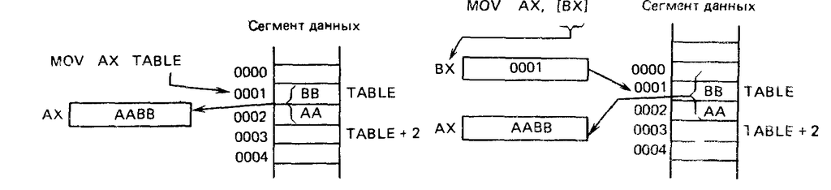

Рис. 3.1. Прямая адресация

Рис. 3.2. Косвенная регистровая адресация

# Косвенная регистровая адресация

При косвенной регистровой адресации исполнительный адрес операнда содержится в базовом регистре ВХ, регистре указателя базы ВР или индексном регистре (SI или DI). Косвенные регистровые операнды надо заключать в квадратные скобки, чтобы отличить их от регистровых операндов. Например, команда `MOV AX,[BX]` загружает в регистр АХ содержимое ячейки памяти, адресуемой значением регистра ВХ (рис. 3.2). Как поместить смещение адреса в регистр ВХ? Один из методов состоит в применении операции OFFSET (смещение) к адресу ячейки памяти. Например, для загрузки слова из ячейки TABLE в регистр AХ можно воспользоваться последовательностью команд

```
MOV BX, OFFSET TABLE
MOV AX, [BX]
```

Эти две команды выполняют те же действия, что и одна команда `MOV AX, TABLE` с той лишь разницей, что в первом случае предыдущее содержимое регистра ВХ уничтожается. Если Вам нужен доступ лишь к одной ячейке памяти (в данном случае TABLE), то разумнее воспользоваться одной командой. Однако для доступа к нескольким ячейкам, начиная с данного базового адреса, гораздо лучше иметь исполнительный адрес в регистре. Почему? Потому что содержимым регистра можно манипулировать, не извлекая каждый раз новый адрес.

Стр. 76

# Адресация по базе

При адресации по базе Ассемблер вычисляет исполнительный адрес с помощью сложения значения сдвига с содержимым регистров ВХ или ВР. Регистр ВХ удобно использовать при доступе к структурированным записям данных, расположенным в разных областях памяти. В этом случае базовый адрес записи помещается в базовый регистр ВХ и доступ к ее отдельным элементам осуществляется по их сдвигу относительно базы. А для доступа к разным записям одной и той же структуры достаточно соответствующим образом изменить содержимое базового регистра. Предположим, например, что требуется прочитать с диска учетные записи для ряда работников. При этом каждая запись содержит табельный номер работника, номер отдела, номер группы, возраст, тарифную ставку и т.д. Если номер отдела

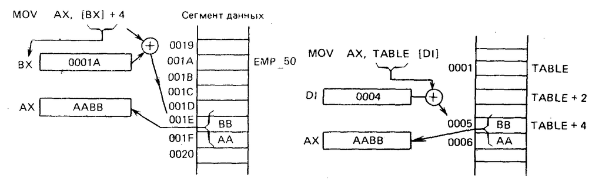

Рис. 3.3. Адресация по базе

Рис. 3.4. Прямая адресация с индексированием

хранится в пятом и шестом байтах записи, а начальный адрес записи содержится в регистре ВХ, то команда `MOV AX,[BX]+4` загрузит в регистр АХ номер отдела, в котором служит данный работник (рис. 3.3). (Сдвиг равен 4, а не 5, потому что первый байт записи имеет номер 0.) Ассемблер фирмы IBM позволяет указывать адресуемые по базе операнды тремя разными способами. Следующие команды эквивалентны:

```
MOV AX, [BP]+4   ; Это стандартная торма записи,
MOV AX, 4 [BP]    ;но сдвиг можно указать на первом месте
MOV AX, [BP+4]   ; или внутри скобок
```

# Прямая адресация с индексированием

При прямой адресации с индексированием исполнительный адрес вычисляется как сумма значений сдвига и индексного регистра (DI или SI). Этот тип адресации удобен для доступа к элементам таблицы, когда сдвиг указывает на начало таблицы, а индексный регистр - на ее элемент. Например, если B_TABLE - таблица байтов, то последовательность команд

```
MOV DI,2
MOV AL, B_TABLE[DI]
```

загрузит третий элемент таблицы в регистр AL. В таблице слов соседние элементы отстоят друг от друга на два байта, поэтому при работе с ней надо удваивать номер элемента при вычислении значения индекса. Если TABLE - таблица слов, то для загрузки в регистр AX ее третьего элемента надо использовать последовательность команд (рис. 3.4.)

```
MOV DI, 4
MOV AX, TABLE[DI]
```

Стр. 77

# Адресация по базе с индексированием

При адресации по базе с индексированием исполнительный адрес вычисляется как сумма значений базового регистра, индексного регистра и, возможно, сдвига.

```
MOVE AX, [BX+2+DI]  ; Операнды можно заключать в скобки в любом
MOVE AX, [DI+BX+2]  ; порядке, а сдвиг можно сочетать с любым
MOVE AX, [BX+2][DI] ; из регистров
MOVE AX, [BX][DI+2]
```

Стр. 78

# 3.3 Типы команд

Как уже упоминалось, микропроцессор 8088 имеет 92 типа команд. В табл. 3.2 приведены их мнемокоды на языке ассемблера и кратко указано назначение. Учтите, что некоторые команды имеют по нескольку разных мнемокодов.

- Мнемокод - Назначение
- ΑΑΑ - Скорректировать сложение для представления в кодах ASCII
- AAD - Скорректировать деление для представления в кодах ASCII
- ΑΑΜ - Скорректировать умножение для представления в кодах ASCII
- AAS - Скорректировать вычитание для представления в кодах ASCII
- ADC - Сложить с переносом
- ADD - Сложить
- AND - Выполнить операцию И
- CALL - Вызвать процедуру
- CBW - Преобразовать байт в слово
- CLC - Обнулить флаг переноса
- CLD - Обнулить флаг направления
- CLI - Обнулить флаг прерывания
- СМС - Обратить флаг переноса
- CMP - Сравнить значения
- Мнемокод - Назначение
- CMPS, CMPSB или CMPSW - Сравнить строки
- CWD - Преобразовать слово в двойное слово
- DAA - Скорректировать сложение для представления в десятичной форме
- DAS - Скорректировать вычитание для представления в десятичной форме
- DEC - Уменьшить значение
- DIV - Поделить
- ESC - Передать команду сопроцессору
- HLT - Остановиться
- IDIV - Разделить целые числа
- IMUL - Умножить целые числа
- In - Считать значение из порта
- INC - Прирастить значение
- INT - Прервать
- INTO - Прервать при переполнении
- IRET - Возвратиться после прерывания

Стр. 79

- Мнемокод - Назначение
- JA или JNBE - Перейти, если выше
- JAE, JNB или - Перейти, если выше или равно
- JNC - Перейти, если нет переноса
- JB, JNAE или - Перейти, если ниже
- JC - Перейти, если перенос
- JBE или JNA - Перейти, если ниже или равно
- JCXZ - Перейти, если содержимое регистра СХ равно нулю
- JE или JZ - Перейти, если равно
- JG или JNLE - Перейти, если больше
- JGE или JNL - Перейти, если больше или равно
- JL или JNGE - Перейти, если меньше
- Мнемокод - Назначение
- JLE или JNG - Перейти, если меньше или равно
- JMP - Перейти безусловно
- JNE или JNZ - Перейти, если не равно
- JNO - Перейти, если нет переполнения
- JNP или JPO - Перейти, если нет четности
- JNS - Перейти, если знаковый разряд нулевой
- JO - Перейти, если переполнение
- JP или JPE - Перейти, если есть четность
- JS - Перейти, если знаковый разряд равен 1
- LAHF - Загрузить регистр АН флагами
- LDS - Загрузить указатель с использованием регистра DS
- Мнемокод - Назначение
- LEA - Загрузить исполнительный адрес
- LES - Загрузить указатель с использованием регистра ES
- LOCK - Замкнуть шину
- LODS, LODSB - или LODSW - Загрузить строку
- LOOP - Повторять цикл до конца счетчика
- LOOPE или LOOPZ - Повторять цикл, если равно

Некоторые из описанных команд уже не используются от слова совсем. Например, в программировании под Windows не использвутеся LOOP. Да и в более старых системах LOOP не поддерживало вложенные циклы. Также мы можем в современном ассемблере совсем не найти команд LEA,LES,LODS, LODSB - или LODSW. Вместо почти всех них используется полее поздний `MOWE AX, WORD [A]` .

Стр. 80

Стр. 81

- Мнемокод - Назначение
- STD - Установить флаг направления
- STI - Установить флаг прерывания
- STOS, STOSB или STOSW - Сохранить строку
- SUB - Вычесть
- test - Проверить
- WAIT - Ожидать
- XCHG - Обменять значения
- XLAT - Выбрать значения из таблицы
- XOR - Выполнить операцию ИСКЛЮЧАЮЩЕЕ ИЛИ

Мы можем разделить систему команд на семь функциональных групп:

1. Команды пересылки данных, осуществляющие обмен информацией между регистрами, ячейками данных и портами ввода-вывода.
2. Арифметические команды, выполняющие арифметические операции над двоичными или двоично-десятичными (в формате BCD - binary-coded decimal) числами.
3. Команды манипулирования битами, выполняющие сдвиг, циклический сдвиг и логические операции со значениями регистров и ячеек памяти.
4. Команды передачи управления, управляющие последовательностью исполнения команд программы. К ним относятся переходы к другой команде, вызов процедуры и возврат из нее.
5. Команды обработки строк, перемещающие, сравнивающие и сканирующие строки данных.
6. Команды прерывания, отвлекающие микропроцессор на обработку некоторых специфичных ситуаций.
7. Команды управления процессором, устанавливающие и сбрасывающие флаги состояния, а также изменяющие режим функционирования микропроцессора. В следующих разделах мы опишем систему команд микропроцессора 8088 по группам в перечисленном выше порядке. Начнем с группы команд пересылки данных, которая содержит вездесущую команду MOV.

Стр. 82

# 3.4. КОМАНДЫ ПЕРЕСЫЛКИ ДАННЫХ

| Мнемокод | Формат | OF | DF | IF | TF | SF | ZF | AF | PF | CF |
| --- | --- | --- | --- | --- | --- | --- | --- | --- | --- | --- |
| Команды пересылки адреса |  |  |  |  |  |  |  |  |  |  |
| LEA | LEA регистр 16, память 16 |  |  |  |  |  |  |  |  |  |
| LDS | LDS регистр 16, память 32 |  |  |  |  |  |  |  |  |  |
| LES | LES регистр 16, память 32 |  |  |  |  |  |  |  |  |  |
| Команды пересылки флагов |  |  |  |  |  |  |  |  |  |  |
| LAHF | LAHF |  |  |  |  |  |  |  |  |  |
| SAHF | SAHF | --- | --- | --- | --- | SF | ZF | AF | PF | CF |
| PUSHF | PUSHF |  |  |  |  |  |  |  |  |  |
| POPF | POPF | OF | DF | IF | TF | SF | ZF | AF | PF | CF |

Примечание.* означает изменение значения флага, - означает его сохранение.

Стр. 83

Приведемнесколько примеров:

```
MOV AX,TABLE     ; Пересылка памяти в регистр
MOV TABLE,AX     ; и наоборот
MOV ES:[BX],AX   ; Можно заменить используемый регистр сегмента
MOV DS,AX        ; Пересылка между 16 Битными регистрами
MOV BL,AL        ; Пересылка между регистрами
MOV CL,-30       ; Пересылка константы регистры
MOV DEST,25H     ; или в память
```

В команде MOV исключаются следующие сочетания операндов:

1.Вы не можете осуществить непосредственную пересылку данных из одной ячейки памяти в другую. Чтобы выполнить такую пе ресылку, данные источника надо загрузить в регистр общего назначения, а затем запомнить содержимое этого регистра в приемнике. Например, если POUNDS и WEIGHT - переменные, находящиеся в памяти, то для пересылки значения из одной переменной в другую можно воспользоваться командами

```
NOV AX,POUNDS
MOV WEIGHT,AX
```

2.Вы не можете загрузить непосредственно адресуемый операнд в регистр сегмента. Как и в случае 1, сначала надо загрузить его в регистр общего назначения. Например, следующие команды загружают номер блока сегмента данных (DATA_SEG) в регистр DS:

```
MOV AX, DATA_SEG
MOV DS,AX
```

Подобные команды обычно сопутствуют оператору ASSUME в сегменте команд. Они указывают Ассемблеру, где размещен сегмент данных.

3.Вы не можете непосредственно переслать значение одного регистра сегмента в другой. Делайте подобные пересылки через регистр общего назначения. Например, чтобы регистр DS указывал на тот же сегмент, что и регистр ES, воспользуйтесь командами

```
MOV AX, ES
MOV DS, AX
```

(Для выполнения этой операции можно воспользоваться командами PUSH и POP, которые будут описаны в следующем разделе.)

1. Вы не можете использовать регистр CS в качестве приемника в команде пересылки.

Стр. 84

# Команды push и pop

Как уже упоминалось, во время исполнения процедуры стек содержит адрес возврата. Команда вызова процедуры CALL (call - вызвать) помещает адрес в стек, а команда возврата RET (return - возвратить) извлекает его по окончании исполнения процедуры. Это один из случаев, когда микропроцессор 8088 использует стек автоматически, без Вашего на то указания. Таким образом, стек удобен для временного сохранения данных (содержимого регистров и ячеек памяти) при работе Вашей программы. Например, Вам может понадобиться сохранить содержимое регистра АХ на то время, пока он требуется для выполнения каких-либо действий. В Вашем распоряжении имеются две команды для работы со стеком - PUSH (поместить слово в стек) и POP (извлечь слово из стека). Команда PUSH помещает содержимое регистра или ячейки памяти размером в 16-битовое слово на вершину стека. А команда РОР, наоборот, снимает слово с вершины стека и помещает его в ячейку памяти или регистр. Команды PUSH и POP имеют следующие форматы:

```
PUSH источник
POP приемник
```

Приведем несколько примеров:

```
PUSH SI            ;Вы можете сохранить регистр общего назначения
PUSH DS            ; или регистр сегмента,
PUSH CS            ;включая регистр CS
PUSH COUNTER       ;Вы можете также сохранить содержимое
PUSH TABLE[BX][DI] ;ячейки памяти
```

Будучи взаимно обратными командами, PUSH и POP обычно используются парами, т.е. каждой команде PUSH в программе должна соответствовать своя команда РОР. Например, при сохранении содержимого регистра АХ в стеке и последующем его восстановлении Ваша программа будет иметь вид

```
PUSH AX ; Сохранить Ах на вершине стека
...     ; (Другие операции, изменяющие содержимое Ах)
POP AX  ; Снять значение Ах с вершины стека
```

Под вершиной стека мы понимаем ячейку в сегменте стека, адрес которой содержится в указателе стека SP. Так как стек "растет" по направлению к младшим адресам памяти (к ячейке 0), то первое помещаемое в стек слово запоминается в ячейке стека с наибольшим адресом, следующее - на два байта ниже и т.д. Регистр SP всегда указывает на слово, помещенное в стек последним. Следовательно, команда PUSH вычитает 2 из значения указателя стека, а затем пересылает операнд-источник (слово) в стек. Действуя обратным образом, команда РОP пересылает в операнд-приемник слово, адрес которого содержится в регистре SP, а затем добавляет 2 к содержимому этого регистра. На рис 3.6 показаны состояния

- Стек
- SS:01F8
- SS:01FA
- SS:01FC
- SS:01FE - SP

a) До исполнения команды PUSH AX

- Стек
- SS:01F8
- SS:01FA
- SS:01FC - (AX) - SP
- SS:01FE

Б) После исполнения команды PUSH AX

- Стек
- SS:01F8
- SS:01FA
- SS:01FC - (AX)
- SS:01FE - SP

в) После исполнения команды POP AX

Рис. 3.6. Воздействие команд PUSH и POP на стек

Стр. 85

стека и его указателя до и после использования команд PUSH и POP. В результате исполнения команды PUSH (рис. 3.6, б) указатель стека передвинется на два байта памяти ниже, и в этих байтах (ранее не используемых) будет содержаться значение регистра АХ. В результате исполнения команды РОР (рис. 3.6, в) содержимое регистра SP вернется в исходное состояние. (Обратите внимание на то, что хотя содержимое регистра АХ по-прежнему находится в памяти, оно не принадлежит стеку.) С помощью серии команд PUSH в стеке можно сохранить более одного слова. Однако помните, что каждая команда PUSH помещает свой операнд на вершину стека, и поэтому с помощью команды РОР Вы будете извлекать слова в порядке, обратном их помещению. Следующая последовательность команд помещает значения четырех регистров в стек, а затем восстанавливает их:

```
PUSH AX     ; Сохранить Ах,
PUSH ES     ; ES
PUSH DI     ; DI и
PUSH SI     ; Si
...
...
PDP SI      ; Восстановить S1,
PDP DI      ; DI
POP ES      ;  ES и
POP AX      ;   AX
```

Команды PUSH и POP удобны также для копирования содержимого одного регистра сегмента в другой. Например, с помощью команд

```
PUSH ES
POP DS
```

можно скопировать значение регистра ES в регистр DS. Этот метод обладает тем преимуществом, что при его применении не надо использовать регистр общего назначения для промежуточного копирования значения регистра сегмента (см. предыдущий подраздел). А его недостаток заключается в том, что исполнение пары команд PUSH-POP занимает 26 циклов тактового генератора, в то время как пара команд MOV исполняется всего за 4 цикла. Для помещения в стек и извлечения из него содержимого флагов имеются специальные команды. Мы рассмотрим их в подразделе "Команды пересылки флагов".